# A0

EJERCICIO 0

Ejercicio 1

Usando la función sample crea un vector dado_honesto con 100 números del 1 al 6. Haz una tabla de frecuencias absolutas (de dos maneras, con table y dplyr) y una tabla de frecuencias relativas.

```r
dado_honesto = sample(1:6, 100, replace = TRUE)
```

Frecuencias absolutas -> con table

```r
table(dado_honesto)
```

```
## dado_honesto
##  1  2  3  4  5  6
## 15 24 13 14 20 14
```

Frecuencias absolutas -> con dplyr

```r
library(dplyr)
tabla<-data.frame(dado_honesto)
tabla %>%
  group_by(dado_honesto) %>%
  summarise(frequency=n())
```

```
## # A tibble: 6 × 2
##   dado_honesto frequency
##          <int>     <int>
## 1            1        15
## 2            2        24
## 3            3        13
## 4            4        14
## 5            5        20
## 6            6        14
```

Frecuencias Relativas

```r
tabla %>%
  group_by(dado_honesto) %>%
  summarise(frequency=n()/100)
```

```
## # A tibble: 6 × 2
##   dado_honesto frequency
##          <int>     <dbl>
## 1            1      0.15
## 2            2      0.24
## 3            3      0.13
## 4            4      0.14
## 5            5      0.2
## 6            6      0.14
```

Ejercicio 2

EJERCICIO 1. ANÁLISIS EXPLORATORIO DE UN CONJUNTO DE DATOS Y OPERACIONES CON DPLYR

1. Carga el conjunto de datos en un data.frame de R llamado chlstrl.
2. Cuántas observaciones contiene,cuáles son las variables y de qué tipos

```r
# Datos del fichero. La url, incluyendo el nombre del fichero.
library(tidyverse)
chlstrl<-read_csv("cholesterol.csv")
glimpse(chlstrl)
```

```
## Rows: 403
## Columns: 7
## $ chol   <dbl> 203, 165, 228, 78, 249, 248, 195, 227, 177, 263, 242, 215, 238,…
## $ age    <dbl> 46, 29, 58, 67, 64, 34, 30, 37, 45, 55, 60, 38, 27, 40, 36, 33,…
## $ gender <chr> "female", "female", "female", "male", "male", "male", "male", "…
## $ height <dbl> 62, 64, 61, 67, 68, 71, 69, 59, 69, 63, 65, 58, 60, 59, 69, 65,…
## $ weight <dbl> 121, 218, 256, 119, 183, 190, 191, 170, 166, 202, 156, 195, 170…
## $ waist  <dbl> 29, 46, 49, 33, 44, 36, 46, 34, 34, 45, 39, 42, 35, 37, 36, 37,…
## $ hip    <dbl> 38, 48, 57, 38, 41, 42, 49, 39, 40, 50, 45, 50, 41, 43, 40, 41,…
```

Tal y como se puede comprobar en este conjunto de datos existen 7 columnas, las cuales son el genero, de tipo character, el colesterol, edad, peso ,altura, cintura y cadera, las cuales son de tipo double, numerico. El número de registros es 403.

3. Asegúrate de comprobar si hay datos ausentes y localízalos en la tabla.

```r
apply(is.na(chlstrl),2,which)
```

```
## $chol
## [1] 28
##
## $age
## integer(0)
##
## $gender
## integer(0)
##
## $height
## [1]  64  87 196 232 318
##
## $weight
## [1] 162
##
## $waist
## [1] 337 394
##
## $hip
## [1] 337 394
```

Análisis de cada variable

4. El análisis exploratorio (numérico y gráfico) debe cubrir todos los tipos de variable de la tabla. Es decir, que al menos debes estudiar una variable por cada tipo de variable presente en la tabla

Se muestra la media de caada variable numérica

```r
library(tidyverse)
chlstrl %>%
  summarise(meanChol=mean(chol,na.rm=TRUE),
            meanAge=mean(age,na.rm=TRUE),
            meanHeight=mean(height,na.rm=TRUE),
            meanWeight=mean(weight,na.rm=TRUE),
            meanHip=mean(hip,na.rm=TRUE),
            meanWaist=mean(waist,na.rm=TRUE))
```

```
## # A tibble: 1 × 6
##   meanChol meanAge meanHeight meanWeight meanHip meanWaist
##      <dbl>   <dbl>      <dbl>      <dbl>   <dbl>     <dbl>
## 1     208.    46.9       66.0       178.    43.0      37.9
```

Se muestran las medianas de cada variable

```r
chlstrl %>%
  summarise(medianChol=median(chol,na.rm=TRUE),
            medianAge=median(age,na.rm=TRUE),
            medianHeight=median(height,na.rm=TRUE),
            medianWeight=median(weight,na.rm=TRUE),
            medianHip=median(hip,na.rm=TRUE),
            medianWaist=median(waist,na.rm=TRUE))
```

```
## # A tibble: 1 × 6
##   medianChol medianAge medianHeight medianWeight medianHip medianWaist
##        <dbl>     <dbl>        <dbl>        <dbl>     <dbl>       <dbl>
## 1        204        45           66         172.        42          37
```

```r
chlstrl %>%
  summarise(varChol=var(chol,na.rm=TRUE),
            varAge=var(age,na.rm=TRUE),
            varHeight=var(height,na.rm=TRUE),
            varWeight=var(weight,na.rm=TRUE),
            varHip=var(hip,na.rm=TRUE),
            varWaist=var(waist,na.rm=TRUE))
```

```
## # A tibble: 1 × 6
##   varChol varAge varHeight varWeight varHip varWaist
##     <dbl>  <dbl>     <dbl>     <dbl>  <dbl>    <dbl>
## 1   1975.   266.      15.4     1627.   32.0     32.8
```

A continuación, se muestran los histogramas de algunas variables. Añadiendo la del género que es una variable categórica.

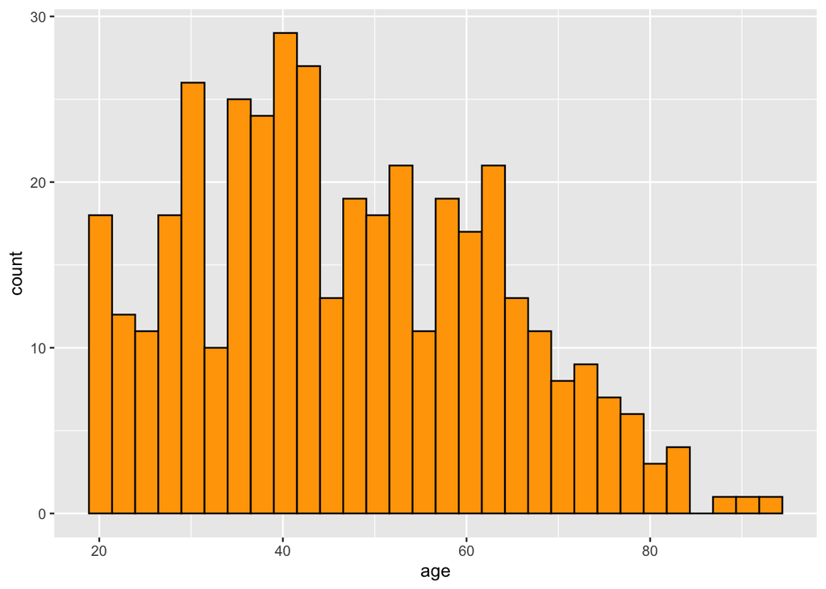

```r
# Histograma Variable Edad
ggplot(data = chlstrl) +
  geom_histogram(mapping = aes(age),
                 fill = "orange", color="black")
```

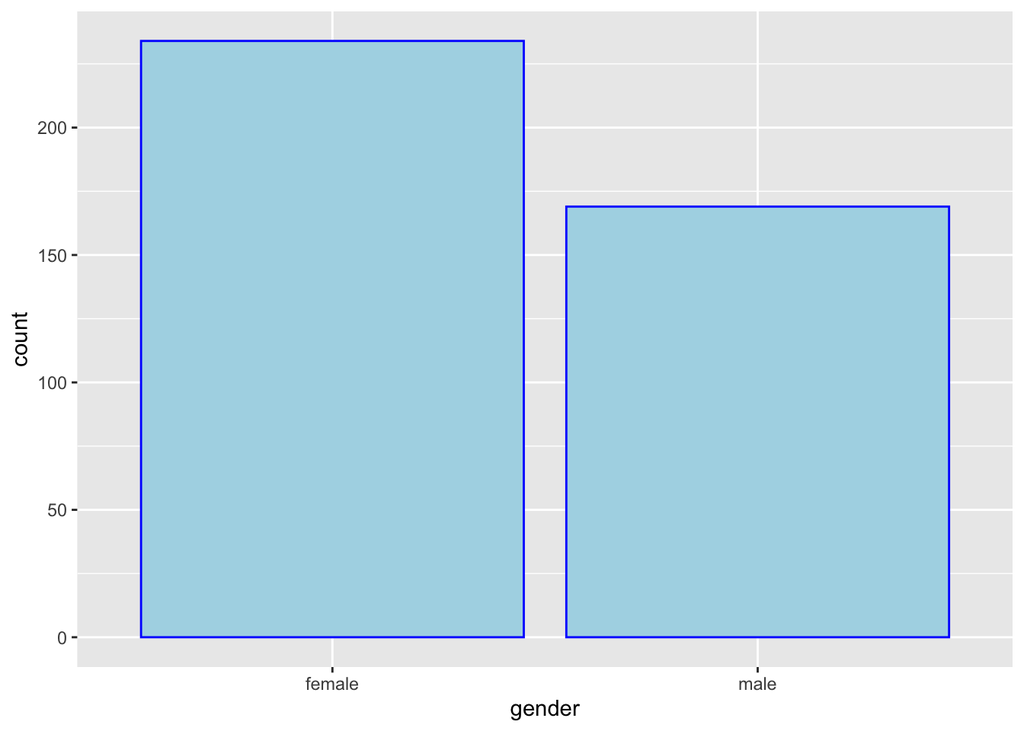

```r
ggplot(data = chlstrl,aes(x=gender)) +
  geom_bar(aes(y=..count..),stat="count",color="blue",fill="light blue")
```

5. Los valores de height y weight están en pulgadas (inches) y libras (pounds) respectivamente. Una libra son ≈ 0.454kg y una pulgada son ≈ 0.0254m. Usa dplyr para convertir esas columnas a metros y kilogramos respectivamente. Las nuevas columnas deben llamarse igual que las originales.

```r
chlstrl2 <- chlstrl %>%
  mutate(height = 0.0254 * height, weight=0.454*weight)
```

6. Ahora usa esos valores de height y weight para añadir una nueva columna llamada BMI

```r
chlstrl2 <- chlstrl2 %>%
  mutate(bmi = (weight) / (height^2))
chlstrl2
```

```
## # A tibble: 403 × 8
##     chol   age gender height weight waist   hip   bmi
##    <dbl> <dbl> <chr>   <dbl>  <dbl> <dbl> <dbl> <dbl>
##  1   203    46 female   1.57   54.9    29    38  22.2
##  2   165    29 female   1.63   99.0    46    48  37.5
##  3   228    58 female   1.55  116.     49    57  48.4
##  4    78    67 male     1.70   54.0    33    38  18.7
##  5   249    64 male     1.73   83.1    44    41  27.8
##  6   248    34 male     1.80   86.3    36    42  26.5
##  7   195    30 male     1.75   86.7    46    49  28.2
##  8   227    37 male     1.50   77.2    34    39  34.4
##  9   177    45 male     1.75   75.4    34    40  24.5
## 10   263    55 female   1.60   91.7    45    50  35.8
## # … with 393 more rows
```

7. Crea una nueva columna llamada ageGroup dividiendo la edad en los siguientes tres niveles: (10,40], (40,70] , (70,100]

```r
func=function(x){
  if(x<=40 & x>10){
    return("(10,40]")
  }else if(x>40 & x<=70){
    return("(40,70]")
  }else if(x>70 & x<=100){
    return("(70,100]")
  }

}

chlstrl2=chlstrl2 %>%
  mutate(ageGroup=func(age))
chlstrl2
```

```
## # A tibble: 403 × 9
##     chol   age gender height weight waist   hip   bmi ageGroup
##    <dbl> <dbl> <chr>   <dbl>  <dbl> <dbl> <dbl> <dbl> <chr>
##  1   203    46 female   1.57   54.9    29    38  22.2 (40,70]
##  2   165    29 female   1.63   99.0    46    48  37.5 (40,70]
##  3   228    58 female   1.55  116.     49    57  48.4 (40,70]
##  4    78    67 male     1.70   54.0    33    38  18.7 (40,70]
##  5   249    64 male     1.73   83.1    44    41  27.8 (40,70]
##  6   248    34 male     1.80   86.3    36    42  26.5 (40,70]
##  7   195    30 male     1.75   86.7    46    49  28.2 (40,70]
##  8   227    37 male     1.50   77.2    34    39  34.4 (40,70]
##  9   177    45 male     1.75   75.4    34    40  24.5 (40,70]
## 10   263    55 female   1.60   91.7    45    50  35.8 (40,70]
## # … with 393 more rows
```

EJERCICIO 2: FUNCIONES DE R

1. Crea una función de R llamada cambiosSigno que dado un vector x de números enteros no nulos, como -12, -19, 9, -13, -14, -17, 8, -19, -14, calcule cuántos cambios de signo ha habido. Es decir, cuántas veces el signo de un elemento es distinto del signo del elemento previo. Por ejemplo, en el vector anterior hay 4 cambios de signo (en las posiciones 3, 4, 7 y 8).

```r
cambiosSigno=function(x){
  num_antiguo=x[1]
  cambios=0
  for(n in x){
    if(n*num_antiguo<0){
      cambios=cambios+1
    }
    num_antiguo=n
  }
  return(cambios)
}

vectorEjemplo =c(-12,-19,9,-13,-14,-17,8,-19,-14)
cambiosSigno(vectorEjemplo)
```

```
## [1] 4
```

2. Modifica la función para que devuelva como resultado las posiciones donde hay cambios de signo. Llama cambiosSignoPos(x) a esa otra función. Por ejemplo, para el vector anterior el resultado de esta función sería [1] 3 4 7 8 También se valorará que incluyas en el código como usar sample para generar vectores aleatorios de 20 enteros no nulos (el vector debe poder tomar valores positivos y negativos).

```r
cambiosSignoPos=function(x){
  num_antiguo=x[1]
  lista=c()
  for(n in 1:length(x)){
    if(x[n]*num_antiguo<0){
      lista=c(lista,n)
    }
    num_antiguo=x[n]
  }
  return(lista)
}
cambiosSignoPos(vectorEjemplo)
```

```
## [1] 3 4 7 8
```

EJERCICIO 3. R4DS

1. Recrea el código R necesario para generar los siguientes gráficos

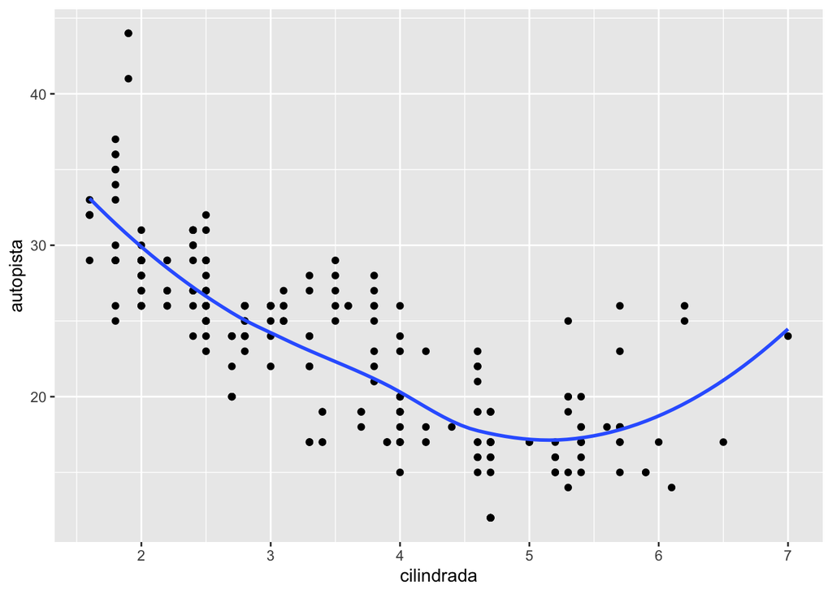

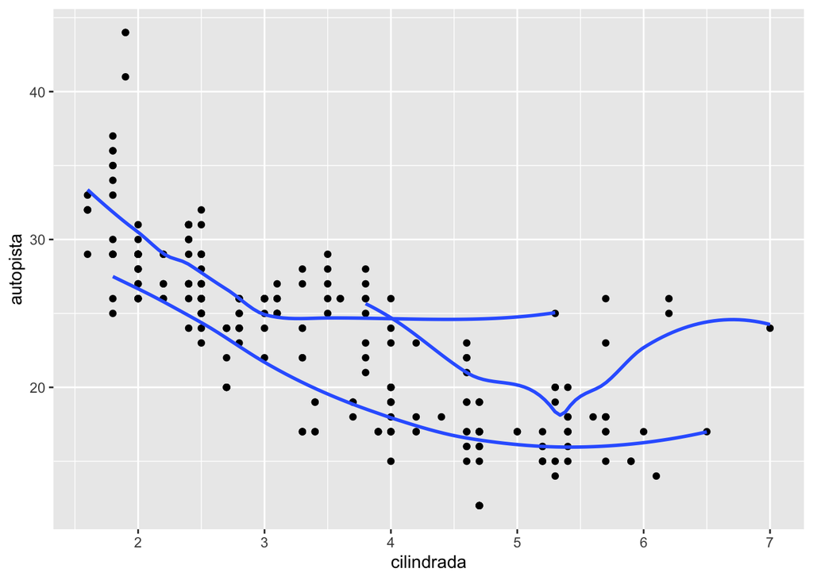

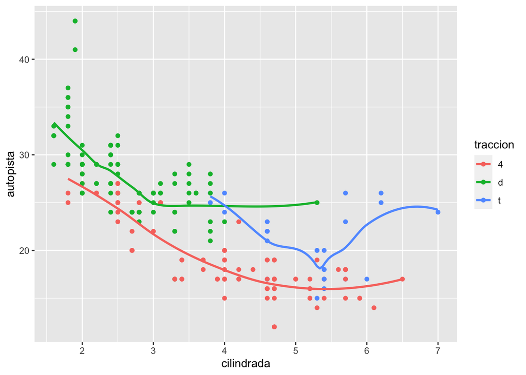

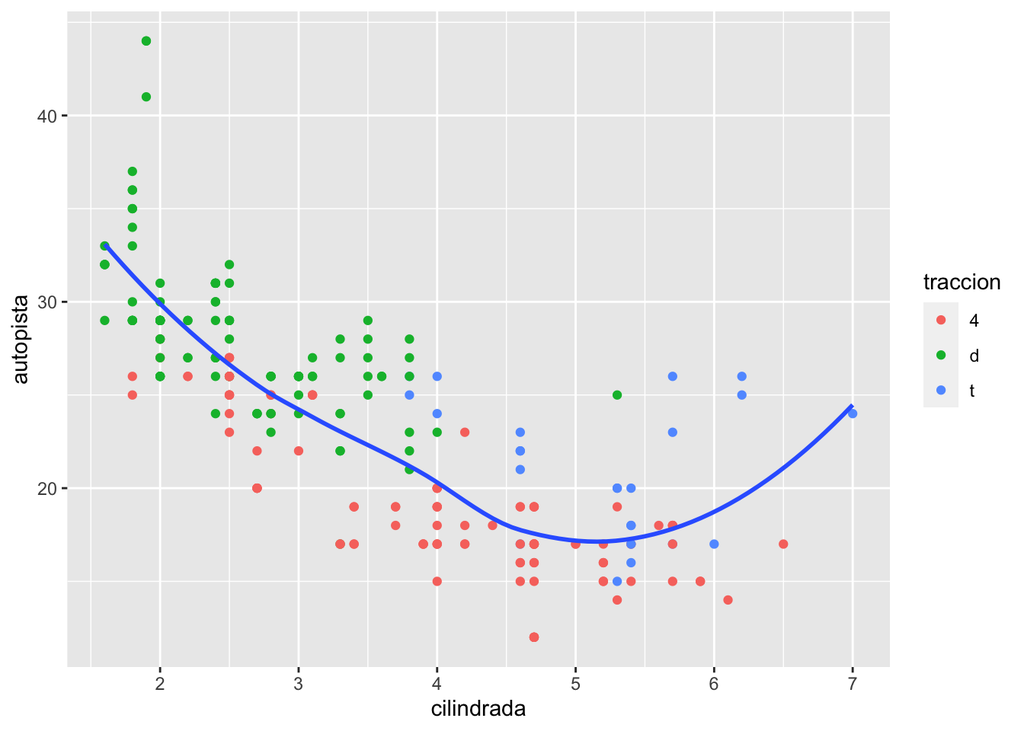

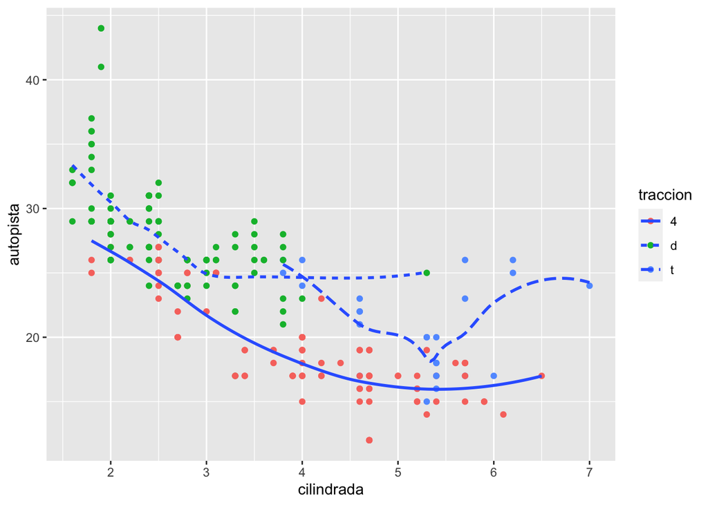

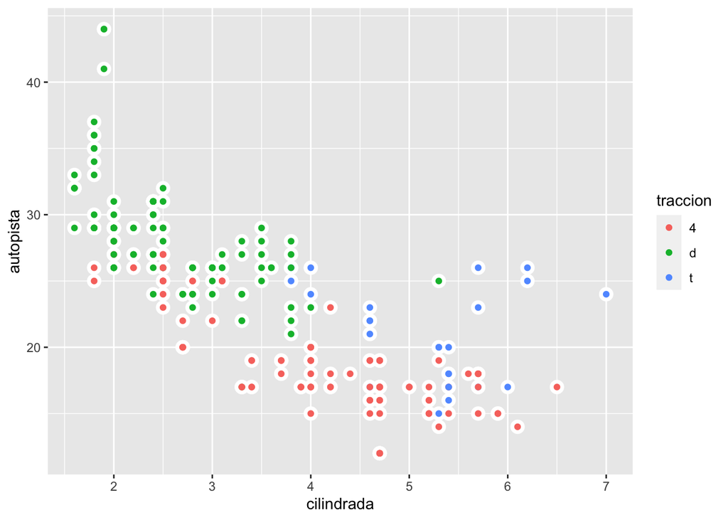

```r
library(datos)
ggplot(data = millas, mapping = aes(x = cilindrada, y = autopista)) +
  geom_point() +
  geom_smooth(se=FALSE)
ggplot(data = millas, mapping = aes(x = cilindrada, y = autopista)) +
  geom_point() +
  geom_smooth(mapping = aes(x = cilindrada, y = autopista, group = traccion),se=FALSE)
ggplot(data = millas, mapping = aes(x = cilindrada, y = autopista, color=traccion)) +
  geom_point() +
  geom_smooth(mapping = aes(x = cilindrada, y = autopista, group = traccion),se=FALSE)
ggplot(data = millas, mapping = aes(x = cilindrada, y = autopista)) +
  geom_point(aes(color=traccion)) +
  geom_smooth(mapping = aes(x = cilindrada, y = autopista), se=FALSE)
ggplot(data = millas, mapping = aes(x = cilindrada, y = autopista, group=traccion) ) +
  geom_point(aes(color=traccion)) +
  geom_smooth( mapping = aes(x = cilindrada, y = autopista, linetype = traccion),se=FALSE)
ggplot(data = millas, mapping = aes(x = cilindrada, y = autopista, group=traccion) ) +
  geom_point(size = 4, colour = "white") +
  geom_point(aes(colour = traccion))
```

2. Haz el ejercicio 1 de la Sección 5.2.4 de R4DS. Encuentra todos los vuelos que: Tuvieron un retraso de llegada de dos o más horas

```r
filter(vuelos,atraso_llegada>=120)
```

```
## # A tibble: 10,200 × 19
##     anio   mes   dia horario_salida salida_programada atraso_salida
##    <int> <int> <int>          <int>             <int>         <dbl>
##  1  2013     1     1            811               630           101
##  2  2013     1     1            848              1835           853
##  3  2013     1     1            957               733           144
##  4  2013     1     1           1114               900           134
##  5  2013     1     1           1505              1310           115
##  6  2013     1     1           1525              1340           105
##  7  2013     1     1           1549              1445            64
##  8  2013     1     1           1558              1359           119
##  9  2013     1     1           1732              1630            62
## 10  2013     1     1           1803              1620           103
## # … with 10,190 more rows, and 13 more variables: horario_llegada <int>,
## #   llegada_programada <int>, atraso_llegada <dbl>, aerolinea <chr>,
## #   vuelo <int>, codigo_cola <chr>, origen <chr>, destino <chr>,
## #   tiempo_vuelo <dbl>, distancia <dbl>, hora <dbl>, minuto <dbl>,
## #   fecha_hora <dttm>
```